# Summary

- ボストンの住宅価格のデータセットについて, データを可視化・考察した上でLightGBMの学習と評価を実施した
- 幾つかの特徴量が目的変数(住宅価格)に対して強い相関が出ていることが分かった
  - **給与所得が低い地域や, 住居当たりの平均部屋数が少ない地域ほど住宅の価格は低い傾向にある**
- 実際にモデルを学習し, SHAPを用いて特徴の寄与度を可視化した結果, LSTAT, RM, NOX等の幾つかの要素がモデルの出力に強く影響していることが分かった
  - 給与所得の低い地域/住居当たりの部屋数が少ない地域/窒素酸化物の濃度が濃い地域は住居の価格が安いと予測される
  - SHAPにおける寄与度と相関係数は必ずしも一致するわけではないが, ある程度は同様の傾向が見られた(=相関が強いものはSHAPにおける寄与度も高い)
- LightGBMでモデルを学習させた結果, RMSEで3.89程度の誤差となった
  - この誤差が許容できるのか/性能改善が必要なのかはビジネス要件に依存する
  - 本来的には, ビジネス要件を踏まえて性能に関する議論を記載すべきだがここには記載しない

```python
import warnings
warnings.filterwarnings('ignore')

import numpy as np
import pandas as pd
from plotly import tools
import plotly.graph_objs as go
import plotly.offline as py
from sklearn.datasets import load_boston
import tensorflow_data_validation as tfdv
from typing import Callable, Dict, Sequence, Union

%matplotlib inline
py.init_notebook_mode()
```

## Define plotly settings and functions

```python
PLOT_COLORS = (
    'rgba(30, 200, 200, 0.8)',
    'rgba(30, 20, 200, 0.8)',
    'rgba(100, 100, 100, 0.8)',
    'rgba(200, 200, 20, 0.8)'
)


def histogram_chart(
    series:Sequence ,
    marker: Dict[str, str]=None,
) -> go.Histogram:
    """get plotly trace"""
    marker = marker if marker else {}
    trace = go.Histogram(
        x=series,
        marker=marker
    )
    return trace


def plot_chart(
    values: Sequence[Sequence],
    titles: Sequence[str],
    chart_func: Callable,
    colors: Sequence[str]
) -> None:
    """plots multiple sequences by plotly"""
    trace_num = len(values)
    traces = []
    for idx, value in enumerate(values):
        trace = chart_func(
            value,
            marker={'color': colors[idx]}
        )
        traces.append(trace)

    fig = tools.make_subplots(
        rows=1,
        cols=trace_num,
        vertical_spacing=0.2,
        subplot_titles=titles
    )
    fig.layout['yaxis']['automargin'] = True

    for idx, trace in enumerate(traces):
        fig.append_trace(trace, 1, idx+1)

    py.iplot(fig)
```

# EDA

```python
data_dict = load_boston()
data = pd.DataFrame(data_dict['data'])
data.columns = data_dict['feature_names']
target = pd.Series(data_dict['target'])
```

## Data Overview

```python
print(f'data shape: {data.shape}')
data.head()
```

```
data shape: (506, 13)
```

|  | CRIM | ZN | INDUS | CHAS | NOX | RM | AGE | DIS | RAD | TAX | PTRATIO | B | LSTAT |
| --- | --- | --- | --- | --- | --- | --- | --- | --- | --- | --- | --- | --- | --- |
| 0 | 0.00632 | 18.0 | 2.31 | 0.0 | 0.538 | 6.575 | 65.2 | 4.0900 | 1.0 | 296.0 | 15.3 | 396.90 | 4.98 |
| 1 | 0.02731 | 0.0 | 7.07 | 0.0 | 0.469 | 6.421 | 78.9 | 4.9671 | 2.0 | 242.0 | 17.8 | 396.90 | 9.14 |
| 2 | 0.02729 | 0.0 | 7.07 | 0.0 | 0.469 | 7.185 | 61.1 | 4.9671 | 2.0 | 242.0 | 17.8 | 392.83 | 4.03 |
| 3 | 0.03237 | 0.0 | 2.18 | 0.0 | 0.458 | 6.998 | 45.8 | 6.0622 | 3.0 | 222.0 | 18.7 | 394.63 | 2.94 |
| 4 | 0.06905 | 0.0 | 2.18 | 0.0 | 0.458 | 7.147 | 54.2 | 6.0622 | 3.0 | 222.0 | 18.7 | 396.90 | 5.33 |

```python
target.head()
```

```
0    24.0
1    21.6
2    34.7
3    33.4
4    36.2
dtype: float64
```

## Target overview

```python
plot_chart(
    values=[target],
    titles=['Target distribution'],
    chart_func=histogram_chart,
    colors=PLOT_COLORS
)
```

```
This is the format of your plot grid:
[ (1,1) x1,y1 ]
```

[interactive chart not shown]

```python
target.describe()
```

```
count    506.000000
mean      22.532806
std        9.197104
min        5.000000
25%       17.025000
50%       21.200000
75%       25.000000
max       50.000000
dtype: float64
```

- targetは正規分布に近い形をしているように見える
- maxがきっかり50となっており, またヒストグラム上の頻度が多くなっているため, 恐らく**50以上の値は全て50に丸め込まれている**と思われる
- meanとmedianはほぼ一致

```python
target.value_counts().sort_index(ascending=False).head(10)
```

```
50.0    16
48.8     1
48.5     1
48.3     1
46.7     1
46.0     1
45.4     1
44.8     1
44.0     1
43.8     1
dtype: int64
```

- 各値の出現頻度を見ると, 実際に50.0の出現頻度が異常に高くなっている
  - **前述の丸め込みに関する仮説は当たっていそう**

## Feature Overview

```python
feature_stats = tfdv.generate_statistics_from_dataframe(data)
tfdv.visualize_statistics(feature_stats)
```

[interactive chart not shown]

c.f. https://scikit-learn.org/stable/datasets/index.html#boston-dataset

- CHAS, RAD, TAXは離散値を, それ以外のカラムは連続値を取っている
- ドキュメントによると,
  - CHASは0/1を取るカラム(ダミー変数)
    - チャールズ川周辺か否か
  - RADは高速道路へのアクセスのしやすさ
  - TAXは1万ドル辺りの不動産税率

```python
data['RAD'].value_counts().sort_index()
```

```
1.0      20
2.0      24
3.0      38
4.0     110
5.0     115
6.0      26
7.0      17
8.0      24
24.0    132
Name: RAD, dtype: int64
```

- 説明文を見る限りRADは順序尺度のように見えるが, 値をソートするといきなり8 -> 24と飛んでいる
  - 名義尺度の可能性もある？
  - categorical_features/numerical_featuresそれぞれで扱うパターンを実験する

## Interaction between Features and Target

```python
data['target'] = target
data.corr()
```

|  | CRIM | ZN | INDUS | CHAS | NOX | RM | AGE | DIS | RAD | TAX | PTRATIO | B | LSTAT | target |
| --- | --- | --- | --- | --- | --- | --- | --- | --- | --- | --- | --- | --- | --- | --- |
| CRIM | 1.000000 | -0.200469 | 0.406583 | -0.055892 | 0.420972 | -0.219247 | 0.352734 | -0.379670 | 0.625505 | 0.582764 | 0.289946 | -0.385064 | 0.455621 | -0.388305 |
| ZN | -0.200469 | 1.000000 | -0.533828 | -0.042697 | -0.516604 | 0.311991 | -0.569537 | 0.664408 | -0.311948 | -0.314563 | -0.391679 | 0.175520 | -0.412995 | 0.360445 |
| INDUS | 0.406583 | -0.533828 | 1.000000 | 0.062938 | 0.763651 | -0.391676 | 0.644779 | -0.708027 | 0.595129 | 0.720760 | 0.383248 | -0.356977 | 0.603800 | -0.483725 |
| CHAS | -0.055892 | -0.042697 | 0.062938 | 1.000000 | 0.091203 | 0.091251 | 0.086518 | -0.099176 | -0.007368 | -0.035587 | -0.121515 | 0.048788 | -0.053929 | 0.175260 |
| NOX | 0.420972 | -0.516604 | 0.763651 | 0.091203 | 1.000000 | -0.302188 | 0.731470 | -0.769230 | 0.611441 | 0.668023 | 0.188933 | -0.380051 | 0.590879 | -0.427321 |
| RM | -0.219247 | 0.311991 | -0.391676 | 0.091251 | -0.302188 | 1.000000 | -0.240265 | 0.205246 | -0.209847 | -0.292048 | -0.355501 | 0.128069 | -0.613808 | 0.695360 |
| AGE | 0.352734 | -0.569537 | 0.644779 | 0.086518 | 0.731470 | -0.240265 | 1.000000 | -0.747881 | 0.456022 | 0.506456 | 0.261515 | -0.273534 | 0.602339 | -0.376955 |
| DIS | -0.379670 | 0.664408 | -0.708027 | -0.099176 | -0.769230 | 0.205246 | -0.747881 | 1.000000 | -0.494588 | -0.534432 | -0.232471 | 0.291512 | -0.496996 | 0.249929 |
| RAD | 0.625505 | -0.311948 | 0.595129 | -0.007368 | 0.611441 | -0.209847 | 0.456022 | -0.494588 | 1.000000 | 0.910228 | 0.464741 | -0.444413 | 0.488676 | -0.381626 |
| TAX | 0.582764 | -0.314563 | 0.720760 | -0.035587 | 0.668023 | -0.292048 | 0.506456 | -0.534432 | 0.910228 | 1.000000 | 0.460853 | -0.441808 | 0.543993 | -0.468536 |
| PTRATIO | 0.289946 | -0.391679 | 0.383248 | -0.121515 | 0.188933 | -0.355501 | 0.261515 | -0.232471 | 0.464741 | 0.460853 | 1.000000 | -0.177383 | 0.374044 | -0.507787 |
| B | -0.385064 | 0.175520 | -0.356977 | 0.048788 | -0.380051 | 0.128069 | -0.273534 | 0.291512 | -0.444413 | -0.441808 | -0.177383 | 1.000000 | -0.366087 | 0.333461 |
| LSTAT | 0.455621 | -0.412995 | 0.603800 | -0.053929 | 0.590879 | -0.613808 | 0.602339 | -0.496996 | 0.488676 | 0.543993 | 0.374044 | -0.366087 | 1.000000 | -0.737663 |
| target | -0.388305 | 0.360445 | -0.483725 | 0.175260 | -0.427321 | 0.695360 | -0.376955 | 0.249929 | -0.381626 | -0.468536 | -0.507787 | 0.333461 | -0.737663 | 1.000000 |

**強い正の相関が出ている特徴**

- RM(平均部屋数)
  - 部屋数が多いほど価格は高くなる？

**強い負の相関が出ている特徴**

- LSTAT(給与の低い職業に従事する人工の割合)
  - 給与が低い地域ほど住宅価格が低くなるのは直感的にも妥当

**負の相関が出ている特徴**

- PTRATIO(教師一人当たりの生徒数)
  - 教師が見る生徒数が多い地域ほど, 恐らくは地域全体の所得も低くなり, 住宅価格も低くなると思われるので妥当
- INDUS(小売業以外の業種が占める面積)
  - 小売業の割合が増えるほど住宅価格が上がる？
    - 都会ほど価格が上がり, 田舎ほど下がるということだろうか？
- TAX(1万ドル当たりの不動産税率)
  - 不動産税率が高いほど住宅価格が下がるのは妥当な印象
    - 同じ値段でも税率が高いと支払金額が高くなってしまい, 割高になるため
- NOX(NOxの濃度)
  - 工場などが設置されている地域は住宅価格が低い？

```python
# targetを削除
data.drop('target', axis=1, inplace=True)
```

# Modeling

```python
from sklearn.metrics import mean_squared_error
from sklearn.model_selection import KFold
import lightgbm as lgb
```

## Train

```python
LGB_PARAMS = {
    'task': 'train',
    'boosting_type': 'gbdt',
    'objective': 'regression',
    'metric': 'rmse',
    'learning_rate': 0.02,
    'num_leaves': 32,
    'subsample': 0.6,
    'subsample_freq': 1,
    'colsample_bytree': 0.22,
    'max_depth': 5,
    'max_bin': 63,
    'reg_alpha': 0.25,
    'reg_lambda': 0.1,
    'min_child_weight': 0.2,
    'min_child_samples': 20,
    'verbose': -1,
    'nthread': -1,
    'seed': 0,
}
FIT_PARAMS = {
    'num_boost_round': 2000,
    'early_stopping_rounds': 20,
    'verbose_eval': 200,
}
```

```python
def split_train_and_valid(
    x_train_valid:Union[pd.DataFrame, np.ndarray],
    y_train_valid:np.ndarray,
    train_indices:np.ndarray,
    valid_indices:np.ndarray
):
    if isinstance(x_train_valid, pd.DataFrame):
        x_train_valid = x_train_valid.values
    return x_train_valid[train_indices], y_train_valid[train_indices], x_train_valid[valid_indices], y_train_valid[valid_indices]
```

```python
feature_names = data.columns.tolist()
scores = []
y_oof = np.zeros(len(target))
kfold = KFold(n_splits=4, random_state=0, shuffle=True)
for train_indices, valid_indices in kfold.split(target):
    x_train, y_train, x_valid, y_valid = split_train_and_valid(data, target, train_indices, valid_indices)
    lgb_train = lgb.Dataset(x_train, y_train, feature_name=feature_names)
    lgb_valid = lgb.Dataset(x_valid, y_valid, feature_name=feature_names)
    evals_result = {}
    model = lgb.train(
        LGB_PARAMS,
        lgb_train,
        valid_sets=[lgb_valid],
        valid_names=['valid'],
        evals_result=evals_result,
        **FIT_PARAMS
    )
    scores.append(model.best_score['valid']['rmse'])
    y_oof[valid_indices] = model.predict(x_valid)
oof_score = np.sqrt(mean_squared_error(target.values, y_oof))
```

```
Training until validation scores don't improve for 20 rounds.
[200]	valid's rmse: 5.92472
[400]	valid's rmse: 5.52304
[600]	valid's rmse: 5.25655
[800]	valid's rmse: 5.11724
[1000]	valid's rmse: 5.03815
Early stopping, best iteration is:
[1167]	valid's rmse: 4.9442
Training until validation scores don't improve for 20 rounds.
[200]	valid's rmse: 3.14631
Early stopping, best iteration is:
[308]	valid's rmse: 2.95035
Training until validation scores don't improve for 20 rounds.
[200]	valid's rmse: 4.21369
[400]	valid's rmse: 3.79272
Early stopping, best iteration is:
[412]	valid's rmse: 3.78538
Training until validation scores don't improve for 20 rounds.
[200]	valid's rmse: 4.83274
[400]	valid's rmse: 4.00259
[600]	valid's rmse: 3.62309
Early stopping, best iteration is:
[612]	valid's rmse: 3.60728
```

## Visualize Difference

```python
print(f'oof rmse: {oof_score}')
```

```
oof rmse: 3.889543353397189
```

```python
diff = target.values - y_oof
plot_chart(
    values=[diff],
    titles=['Distribution of difference between target and prediction'],
    chart_func=histogram_chart,
    colors=PLOT_COLORS
)
```

```
This is the format of your plot grid:
[ (1,1) x1,y1 ]
```

[interactive chart not shown]

- 誤差は比較的きれいな正規分布
- targetの値が大きい場合に, 上手く予測できていないケースが点在

```python
diff_top3_indices = diff.argsort()[::-1][:3]
data.loc[diff_top3_indices]
```

|  | CRIM | ZN | INDUS | CHAS | NOX | RM | AGE | DIS | RAD | TAX | PTRATIO | B | LSTAT |
| --- | --- | --- | --- | --- | --- | --- | --- | --- | --- | --- | --- | --- | --- |
| 372 | 8.26725 | 0.0 | 18.1 | 1.0 | 0.668 | 5.875 | 89.6 | 1.1296 | 24.0 | 666.0 | 20.2 | 347.88 | 8.88 |
| 371 | 9.23230 | 0.0 | 18.1 | 0.0 | 0.631 | 6.216 | 100.0 | 1.1691 | 24.0 | 666.0 | 20.2 | 366.15 | 9.53 |
| 368 | 4.89822 | 0.0 | 18.1 | 0.0 | 0.631 | 4.970 | 100.0 | 1.3325 | 24.0 | 666.0 | 20.2 | 375.52 | 3.26 |

- 予測を大きく間違っているTOP3のケース
- モデルの予測性能を向上させる場合にはこのような事例に関する分析することは有用だが, 今回は特に実施しない

## Analyze model and feature importance

```python
import shap
shap.initjs()
```

```python
feature_importances = pd.DataFrame(
    sorted(
        zip(model.feature_name(), model.feature_importance())
    ), columns=['feature', 'importance']
).sort_values(by='importance', ascending=False)
```

```python
feature_importances
```

|  | feature | importance |
| --- | --- | --- |
| 4 | DIS | 477 |
| 6 | LSTAT | 429 |
| 10 | RM | 412 |
| 0 | AGE | 405 |
| 1 | B | 388 |
| 7 | NOX | 363 |
| 8 | PTRATIO | 321 |
| 3 | CRIM | 318 |
| 11 | TAX | 294 |
| 5 | INDUS | 293 |
| 9 | RAD | 193 |
| 12 | ZN | 92 |
| 2 | CHAS | 4 |

- DIS, LSTAT, RM, AGEのimportanceが大きい
- LSTAT, RMは相関も強く出ていた

```python
# 最後のfoldのモデルを利用
explainer = shap.TreeExplainer(model)
shap_values = explainer.shap_values(data.values)
```

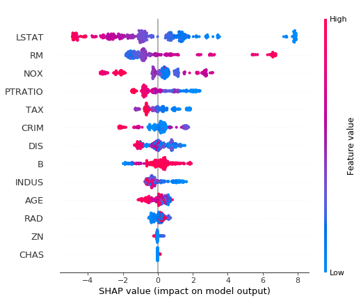

```python
shap.summary_plot(shap_values, data)
```

# Next Action

- RADをcategorical_featureとして扱う
- 予測が間違っているケースに関する分析を深める
  - 同様のtargetを持つケースと比較してどのような要素が異なっているのか

# Proposal

- 本来的には分析・モデリングによって得られた示唆をビジネス的な提案につなげるべきだが, 今回は記載しない
  - 特にActionableな知見がないため